# 第五章 智能交易的云计算平台：以DigitalOcean为例

邱飞

万里学院

## 计算能力是我们实现分析的基础

- 我们的操作流程是：数据 – 分析 – 策略 – 交易
- 数据–分析 – 策略，这三部都需要有计算能力或者说电脑的支撑
- 到目前为止，我们的操作都是在本地电脑（也就是我们自己的电脑上）完成的

## 只用自己的电脑的问题

1. 我的电脑不光是为了运行R语言程序用的，万一程序有冲突怎么办？
2. 我的电脑不可能一天24小时开始，而如果我的设计的算法策略要求电脑不断网随时待命怎么办？
3. 虽然我们的电脑很轻，但是我也没法随时带着它，电脑不在手边的时侯，我需要进行分析操作怎么办？
4. 我想下载海量数据进行大数据分析，但是家里的网络速度太慢怎么办？
5. 我的算法对电脑的配置要求比较高，比如需要32核的处理器，224G的内存，这种配置的电脑市面上都没有卖的，怎么办？

## 云计算平台提供了可伸缩的计算能力

1. 云计算平台首先是提供了一个在线的服务器，只要有浏览器连着网，你可以随时登陆你的服务器进行操作。
2. 云服务平台维护你的服务器，可以做到一天24小时开机运行，且平台的网速超快，不用担心网络的制约问题。
3. 云平台可以方便的调整你的计算能力，当你只是验证想法阶段，你可以选择较低配置的计算能力，比如只需要1核处理器，1G的内存。当你要开始真正干活的时侯，你可以选择高配置计算能力，比如32核处理器，224G内存。
4. 云计算平台一般可以按小时收费，这样可以大大节省费用。

## 云计算平台种类

1. digitalocean是美国的一家云计算平台公司
2. 其他著名的云计算平台还有微软的azure，亚马逊的aws，IBM的Bluemix。他们的共同特点是贵。
3. 国内也有其他的云计算平台，比如阿里云，百度云。他们的特点是也贵，而且缺少教程，还很麻烦。

## 本课程选择的平台

DigitalOcean

1. digitalocean有完善的教程，基本上你想在云平台上实现的事情，都会有详细的帖子教你怎么操作。起步早的云平台比如亚马逊的aws也有这个优点。
2. 国内云平台似乎都是给专家用的，很少有教程文档存在。

## 在DigitalOcean上部署云端Rstudio服务器

- digitalocean 在创建实例的时侯，有个用户设置区，在该区域内写入如下代码：

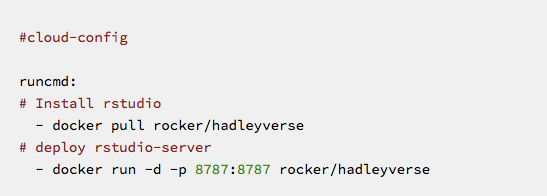

安装完毕后，登陆你的服务器，用户名和密码都为rstudio

## 在自己的服务器上定时更新分析报告

- 假设以下你个场景，毕业后你成为某个基金的操盘手，
- 你需要每天决策买入那题股票，卖出哪些股票，这不是件容易的事情
- 幸运的是，你发现了一个简单的公式，可以告诉你在哪些价格下买入哪些股票，在哪些价格下卖出这些股票！

## 但是问题来了

- 这个公式需要每天载入新数据重新计算，作为极具天赋的金融人才，你有更重要的事情去做，而不想把宝贵实践用在重复计算上。
- 而且，如此宝贵的公式，我不想让别人知道，然而我自己电脑的计算能力又不够？
- 怎么办？

## 于是，你可以在云平台自己配制个服务器

- 在云平台上自己配制服务器，解决计算能力不足的问题(digitalocean平台)
- 设定自动运行的命令，可以自动生成报告（linux下的crontab任务）
- 数据和算法都保存在云端服务器上，不会丢失，也容易保密（云平台和git平台双保险）

## digitalocean的标准服务器

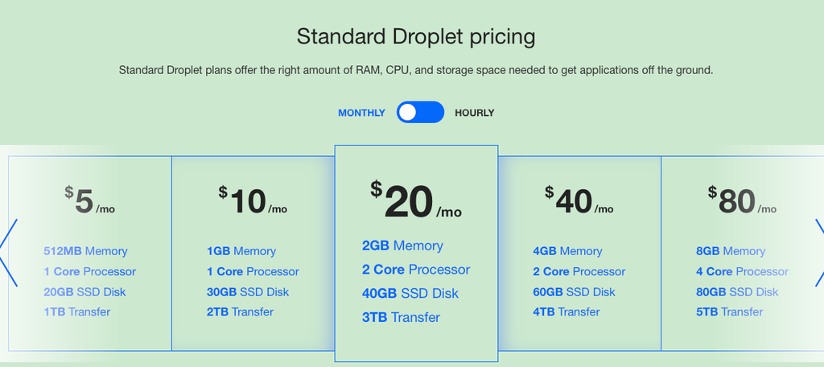

## do上的高性能服务器

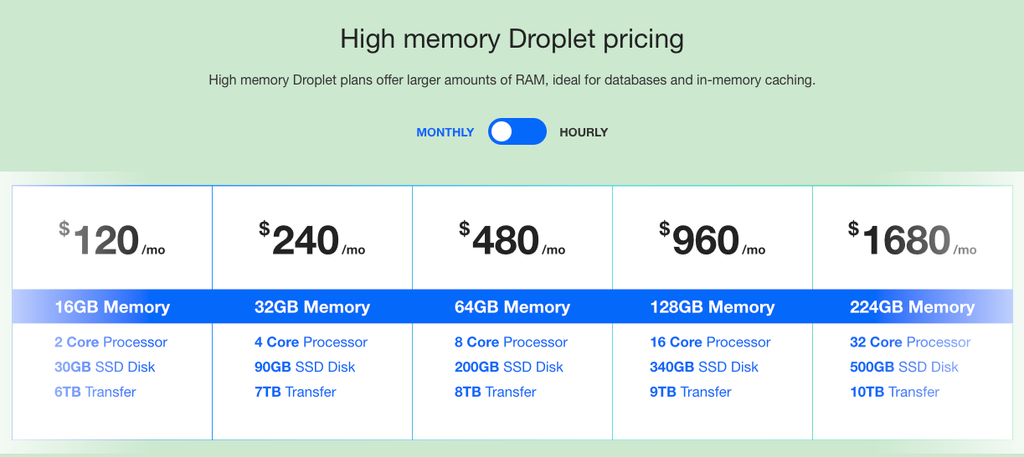

## 自动化设置

- 有了服务器之后，要自动执行你的命令，还需要两部设置
- 首先，把你要做的事情写成shell程序
- 其次，设置crontab命令，按时自动制定你的shell程序

## 登陆云服务器

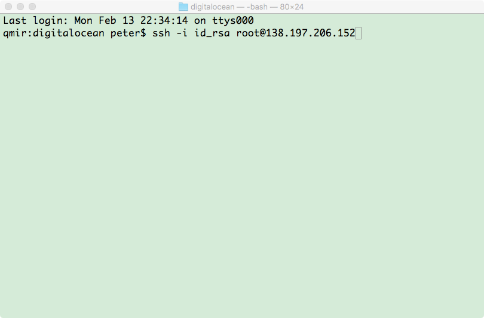

## 登陆后的界面

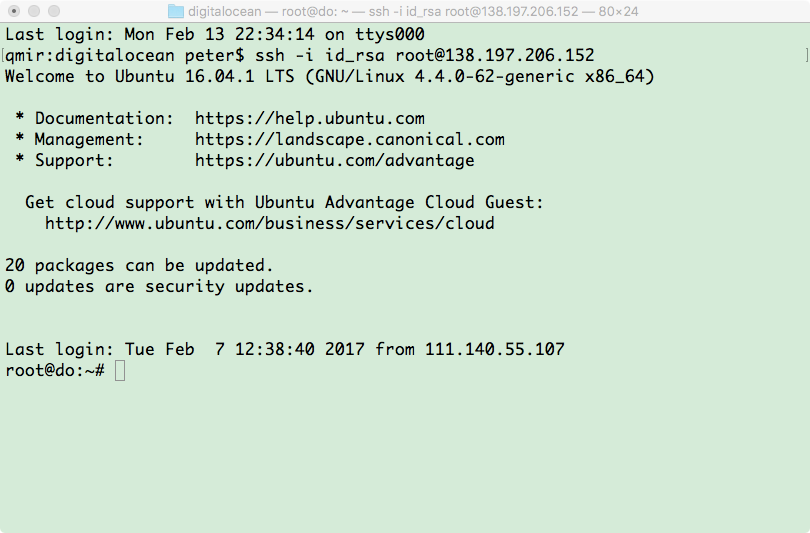

## 将shell脚本改为可执行

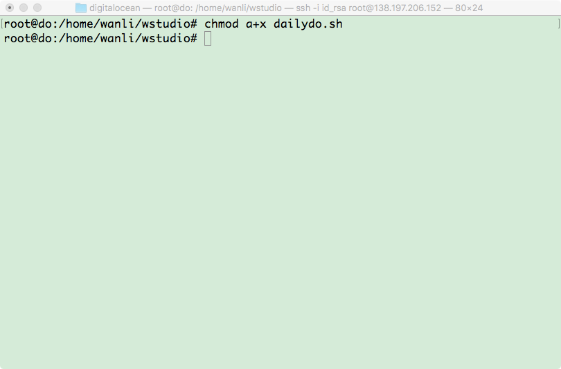

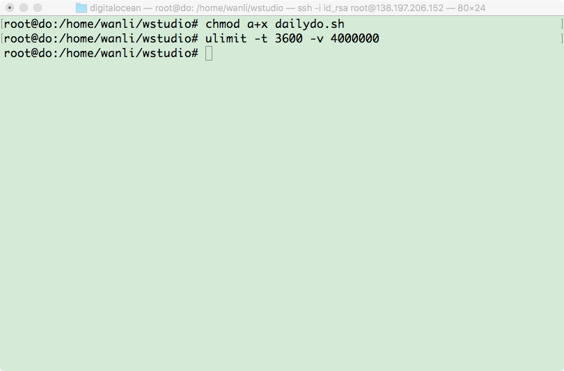

## 自动运行的事件设置

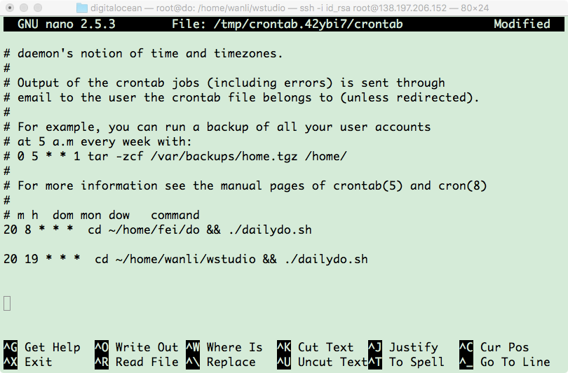

## 用git加crontab来与服务器通信

- 不建议直接登陆使用服务器，因为服务器上同时只能登陆一个用户，如果有人同时登陆，前面登陆的人会被强制退出。
- 所以建议用git来跟服务器沟通，传输资料

## git的基本设置

- git在安装后需要设置邮箱和用户名
- 下面介绍下设置用户名和邮箱的命令，具体怎么使用git来与服务器练通信会在操作课上讲。

## git的邮箱设置

在rstudio的Tools菜单下，点击Shell…，会跳出命令行界面

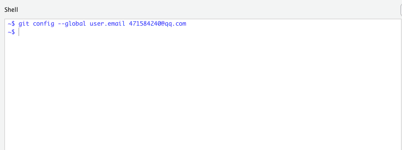

把上面的QQ邮箱地址换成你自己的邮箱。

## git用户名设置

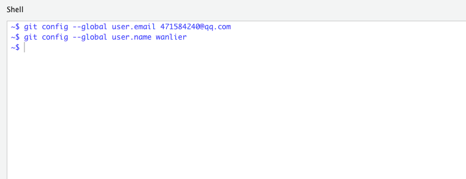

把上面的wanlier换成你自己在github网站注册的用户名，例如hanmeimei1314